# Project 3 Part 2 Terry Troutman

# Derived Variables

There is likely to be a relationship between residual.sugar and acid. The more residual.sugar is present, the more acid is required to balance it. So it makes sense to have a variable with SugarToAcid. SugarToAcid is a the ratio of residual.sugar variable to the fixed.acidity variable. The volatile.acidity measurement is an indicator of spoilage so it was not considered. The balance of salt to sugar is also likely to have an effect on the taste of wine. So another derivied varialble will be SugarToSalt(Chlorides).

```r
wine$SugarToAcid <- wine$residual.sugar / wine$fixed.acidity
wine$SugarToSalt <- wine$residual.sugar / wine$chlorides
```

```
##    Min. 1st Qu.  Median    Mean 3rd Qu.    Max.
##  0.1125  0.2316  0.2727  0.3140  0.3309  2.4820
```

```
##    Min. 1st Qu.  Median    Mean 3rd Qu.    Max.
##   2.946  23.660  28.380  32.010  34.350 238.900
```

# Univariate Plots Section

See Part 1. Memory issue or other unknown bug prevents knitting if file gets too large.

# Bivariate Analysis

## Scatterplots

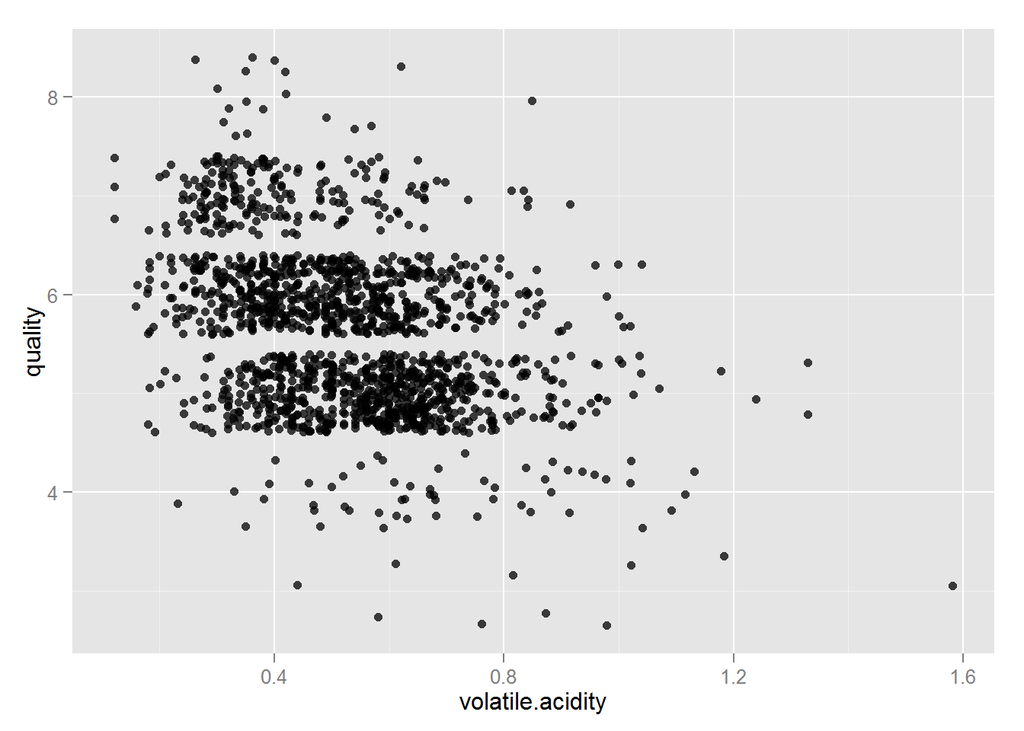

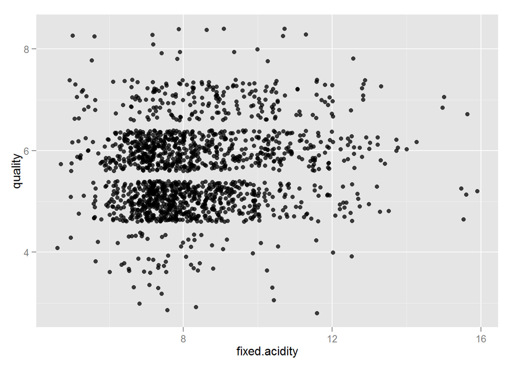

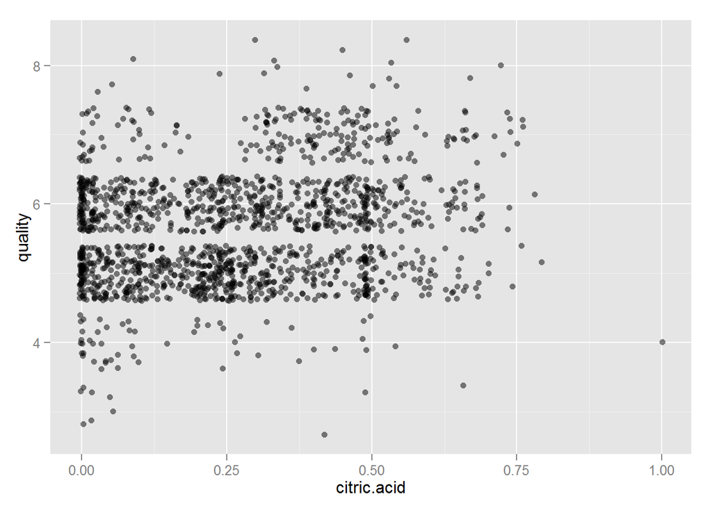

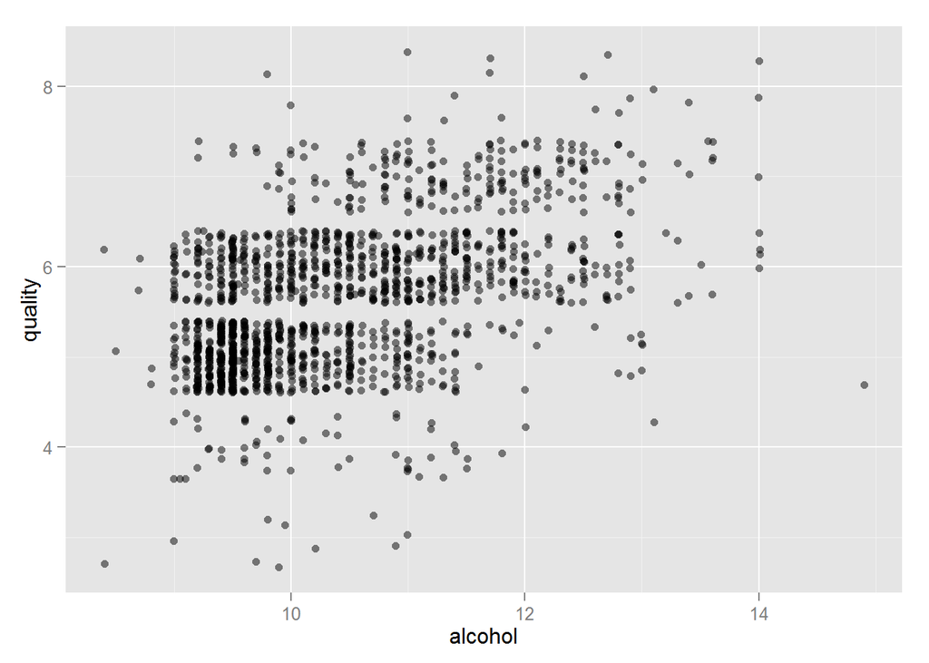

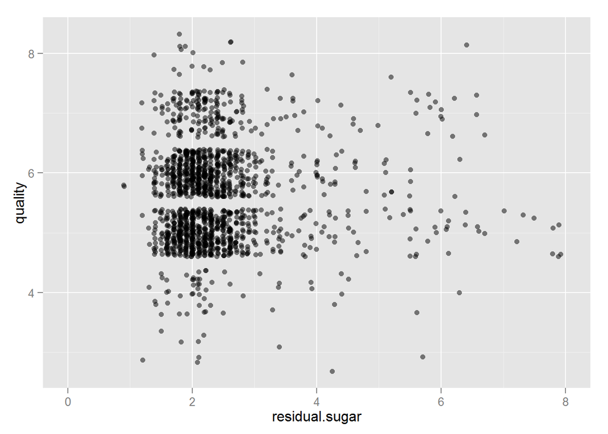

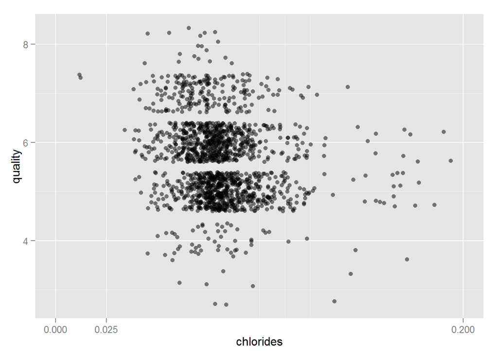

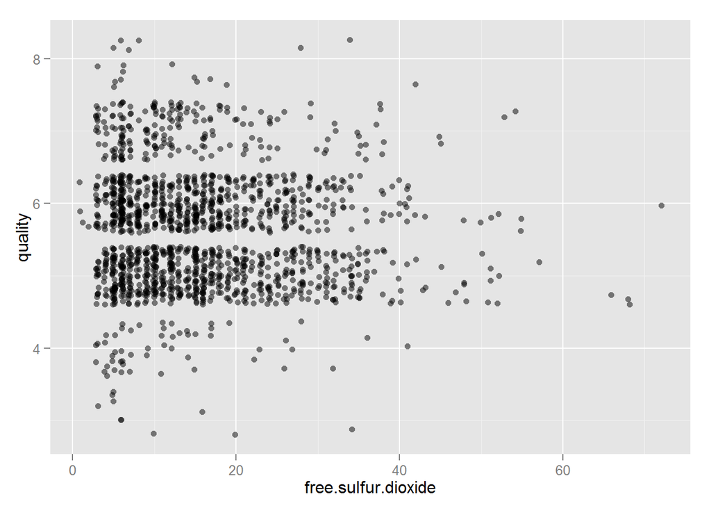

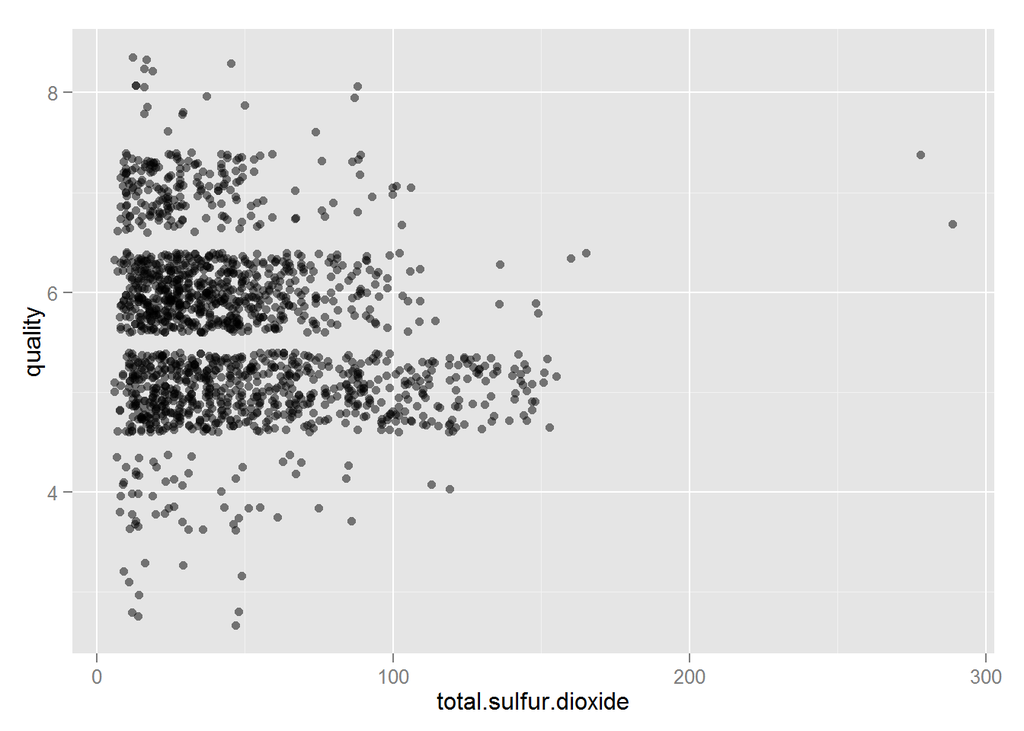

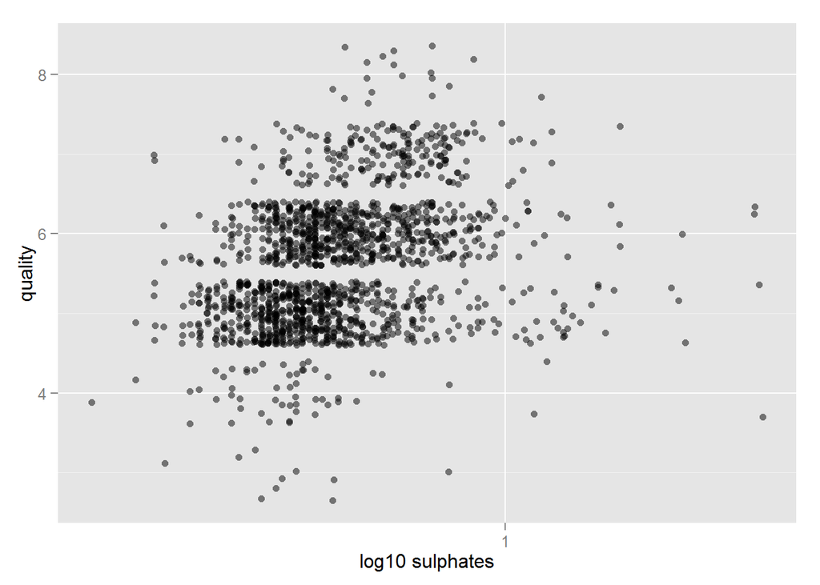

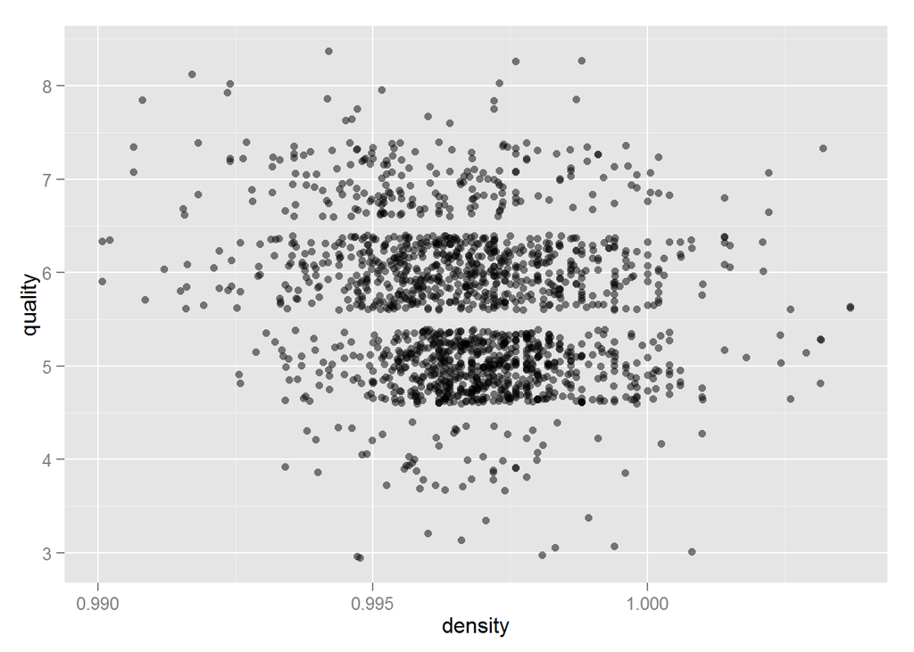

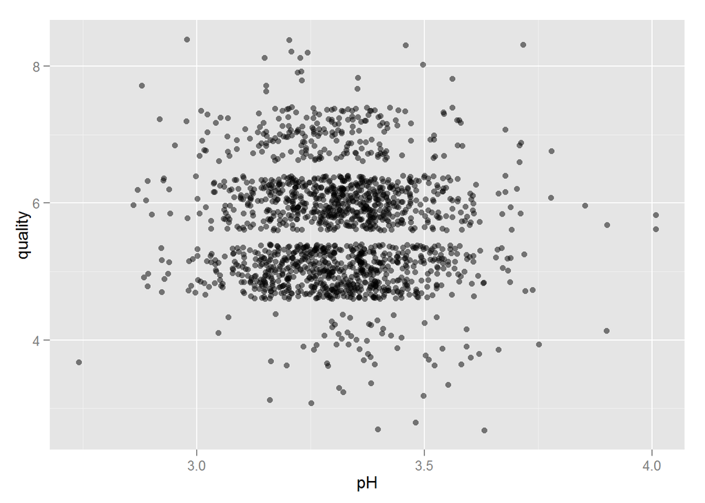

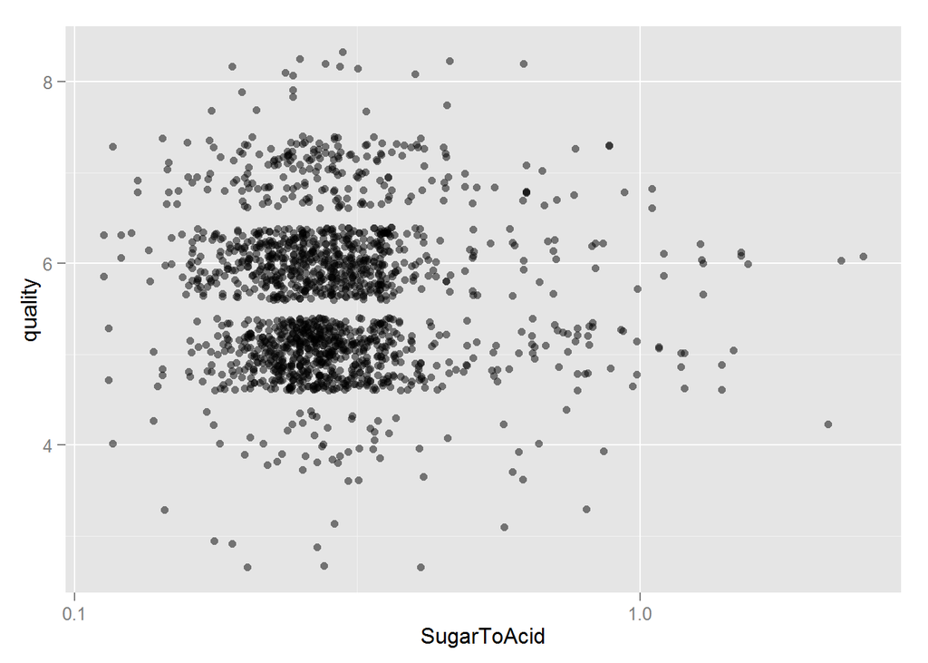

[1 more figures not shown]

### Talk about some of the relationships you observed in this part of the investigation. How did the feature(s) of interest vary with other features in the dataset?

You can say that on average for a given quality, as the volatile acidity increases the quality decreases.

It’s not posbile to make any inferences about fixed acidity adn quality.

It’s not clear from the plots what influence citric acid has on wine quality. It could be argued that as wine alcohol content increases teh quality tends to rise. We are lacking enough data points for certain quality values to definitely make this claim.

It’s not possible to make claims of residual sugars influence on quality.  
Most values lie between 1.5 and 3 and in that range all quality values are represented.

It’s not clear what influence chloride content has on wine. Most values are in a narrow range and in tha range all quality values are present.

It’s not clear how free sulfur dioxide affects quality. There are ranges of values in each quality value.

It’s not clear how total sulfur.dioxide affects quality. There are ranges of value for each quality value.

THere is a very weak correlation between density and wine quality. THe lower quality wines have a higher density on average than the higher quality wines.

There is on clear relationship between pH and wine quality.

THere is no clear relationship between the SugarToAcid ratio and wine quality.

THere is a very weak trend that the higher the SugarToSalt ratio is the higher the wine quality.

### Did you observe any interesting relationships between the other features (not the main feature(s) of interest)?

No.

# Multivariate Analysis Plots and References

Please see Project 3 Part 3. An Unknown bug prevents knitting if the file gets too large.